# hw4

Xinyi Zhu

3/1/2020

```r
library("ggplot2")
library("dplyr")
library("datasets")
```

1. Get a frequency breakdown of the number of chicks, their average weight and the standard deviation of the weights in each of the diets at the start of the study. Store the resulting data frame in a variable named `weight0` and print.

```r
dat1 <- ChickWeight %>% filter(Time == 0)
weight0 <- group_by(dat1, Diet) %>% summarize(n=n(), Mean = mean(weight), StandardDeviation = sd(weight))
print(weight0)
```

```
## # A tibble: 4 x 4
##   Diet      n  Mean StandardDeviation
##   <fct> <int> <dbl>             <dbl>
## 1 1        20  41.4             0.995
## 2 2        10  40.7             1.49
## 3 3        10  40.8             1.03
## 4 4        10  41               1.05
```

extra credit: construct a ggplot that shows average weights by diet with an interval (shown as a line) of +- the standard deviation around the averages

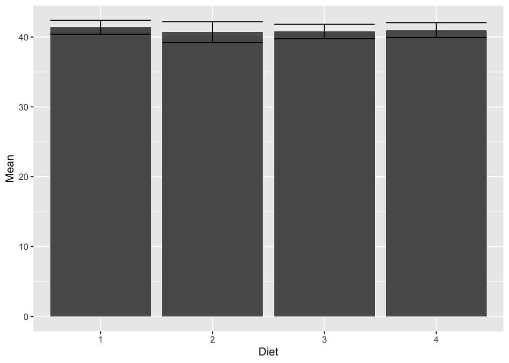

```r
plot <- ggplot(weight0, aes(x=Diet, y = Mean)) + geom_bar(stat = "identity") + geom_errorbar(aes(ymin=Mean-StandardDeviation, ymax=Mean+StandardDeviation))
plot
```

2. Each chick should have twelve weight measurements. Use the `dplyr` package to identify how many measurements are there for each chick. Extract a subset of the data for all chicks with complete information, name the data set `complete`, and print the first 3 rows. (Hint: you might want to use mutate to introduce a helper variable consisting of the number of observations)

```r
check_comp <- group_by(ChickWeight, Chick) %>% summarise(n = n())
check_vec <- check_comp %>% filter(n == max(check_comp$n)) %>% pull(Chick)
complete <- ChickWeight %>% filter(Chick %in% check_vec)
print(complete[0:3, ])
```

```
##   weight Time Chick Diet
## 1     42    0     1    1
## 2     51    2     1    1
## 3     59    4     1    1
```

3. In the complete data set introduce a new variable that measures the current weight difference compared to day 0. Name this variable `weightgain` and print the first 3 rows of the new data frame.

```r
complete <- group_by(complete, Chick) %>% arrange(Chick, Time) %>% mutate(weightgain = weight - first(weight))
print(complete[0:3, ])
```

```
## # A tibble: 3 x 5
## # Groups:   Chick [1]
##   weight  Time Chick Diet  weightgain
##    <dbl> <dbl> <ord> <fct>      <dbl>
## 1     41     0 13    1              0
## 2     48     2 13    1              7
## 3     53     4 13    1             12
```

4. Use `{ggplot2}` to create side-by-side boxplots of `weightgain` by `Diet` for day 21. Change the order of the categories in the Diet variable such that the boxplots are ordered by median `weightgain`, and the lower limit of the y axis should be 0. Describe the relationship in 2-3 sentences.

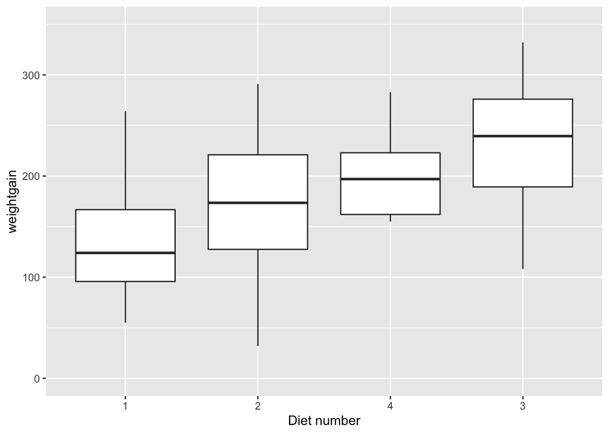

```r
dat2 <- complete %>% filter(Time == 21)
plot1 <- ggplot(dat2, aes(x=reorder(Diet, weightgain, FUN = median), y = weightgain)) + geom_boxplot() +ylim(0,350) + xlab("Diet number")
plot1
```

Diet 1 has the least effect with the least median and diet 3 has the most effect with the highest median. Diet 4 has the smallest range of weightgain.

5. Answer each of the following questions using numerical and graphical summary. Also explain what you found:
1. Which chick gained the most weight and which gained the least weight? (b) What diets were they on?

```r
mostWeight <- dat2 %>% filter(weightgain == max(dat2$weightgain))
leastWeight <- dat2 %>% filter(weightgain == min(dat2$weightgain))
summary(mostWeight)
```

```
##      weight         Time        Chick   Diet    weightgain
##  Min.   :373   Min.   :21   35     :1   1:0   Min.   :332
##  1st Qu.:373   1st Qu.:21   18     :0   2:0   1st Qu.:332
##  Median :373   Median :21   16     :0   3:1   Median :332
##  Mean   :373   Mean   :21   15     :0   4:0   Mean   :332
##  3rd Qu.:373   3rd Qu.:21   13     :0         3rd Qu.:332
##  Max.   :373   Max.   :21   9      :0         Max.   :332
##                             (Other):0
```

```r
summary(leastWeight)
```

```
##      weight        Time        Chick   Diet    weightgain
##  Min.   :74   Min.   :21   24     :1   1:0   Min.   :32
##  1st Qu.:74   1st Qu.:21   18     :0   2:1   1st Qu.:32
##  Median :74   Median :21   16     :0   3:0   Median :32
##  Mean   :74   Mean   :21   15     :0   4:0   Mean   :32
##  3rd Qu.:74   3rd Qu.:21   13     :0         3rd Qu.:32
##  Max.   :74   Max.   :21   9      :0         Max.   :32
##                            (Other):0
```

```r
dat2$new <- ifelse(dat2$weightgain == max(dat2$weightgain), "max", "other")
dat2$new[dat2$weightgain == min(dat2$weightgain)] <- 'min'
dat2
```

```
## # A tibble: 45 x 6
## # Groups:   Chick [45]
##    weight  Time Chick Diet  weightgain new
##     <dbl> <dbl> <ord> <fct>      <dbl> <chr>
##  1     96    21 13    1             55 other
##  2     98    21 9     1             56 other
##  3    117    21 20    1             76 other
##  4    124    21 10    1             83 other
##  5    142    21 17    1            100 other
##  6    157    21 19    1            114 other
##  7    157    21 4     1            115 other
##  8    157    21 6     1            116 other
##  9    175    21 11    1            132 other
## 10    202    21 3     1            159 other
## # … with 35 more rows
```

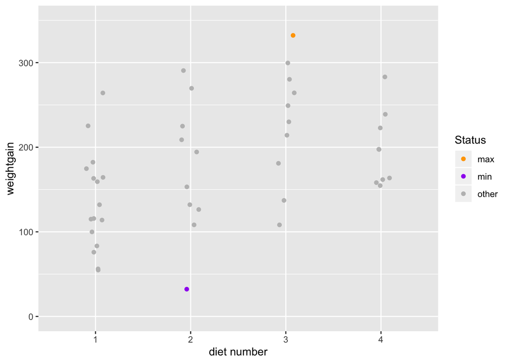

```r
colors <-c("max" = "orange", "min" = "purple", "other" = "grey")
ggplot(dat2, aes(x=Diet, y= weightgain, color=new)) +scale_color_manual("Status", values = colors) + geom_jitter(width = 0.1) + ylim(0,350) +xlab("diet number")
```

6. For the chicks with the least and the most weight at time 0, plot their growth trajectories over time.

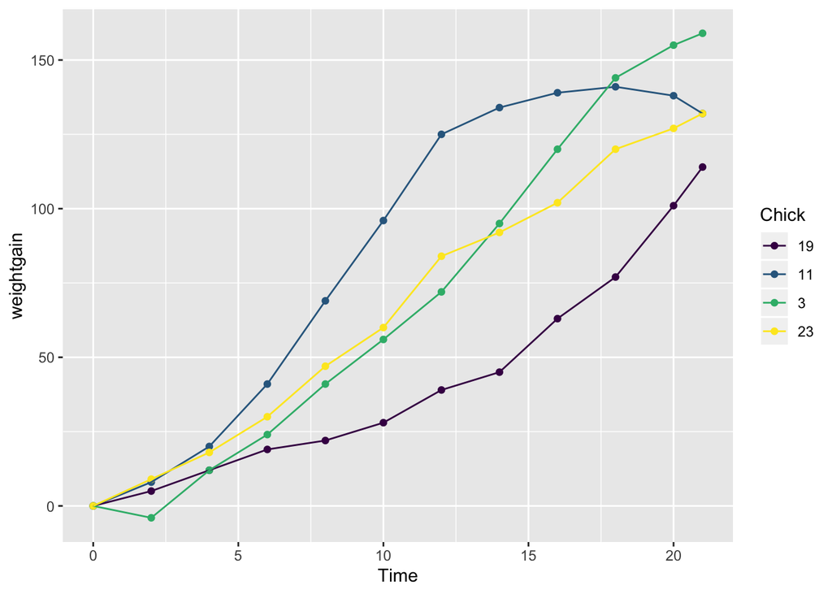

```r
most_chick <-group_by(complete, Time) %>% filter(Time == 0) %>% mutate(max_weight = max(weight)) %>% filter(weight == max_weight) %>% pull(Chick)
least_chick <- group_by(complete, Time) %>% filter(Time == 0) %>% mutate(min_weight = min(weight)) %>% filter(weight == min_weight) %>% pull(Chick)
dat3 <- complete %>% filter(Chick %in% most_chick)
dat4 <- complete %>% filter(Chick %in% least_chick)
plot2 <- ggplot(dat3, aes(x= Time, y = weightgain)) + geom_point(aes(color = Chick)) + geom_line(aes(color = Chick))
plot3 <- ggplot(dat4, aes(x= Time, y = weightgain)) + geom_point(aes(color = Chick)) + geom_line(aes(color = Chick))
plot2
```

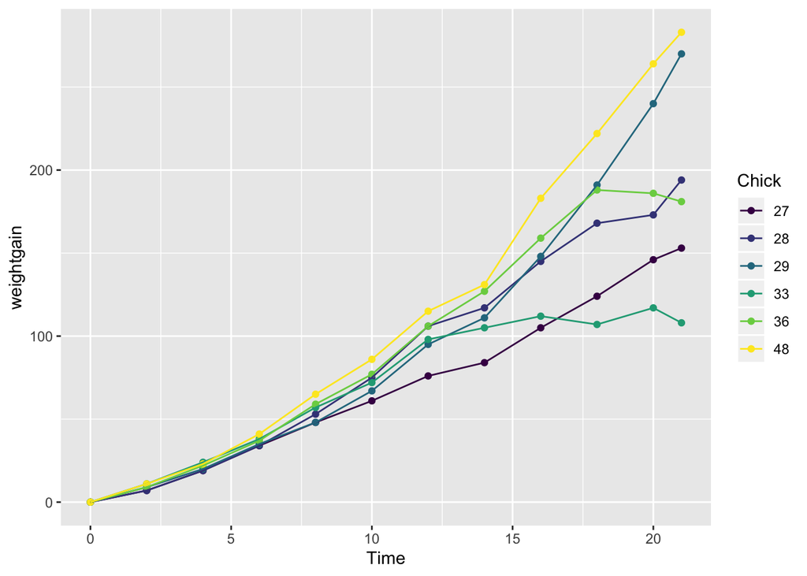

```r
plot3
```

7. Add to the previous plot the average growth trajectory for all chicks (calculated as the mean weight for each chick at each time). How do the trajectories compare?

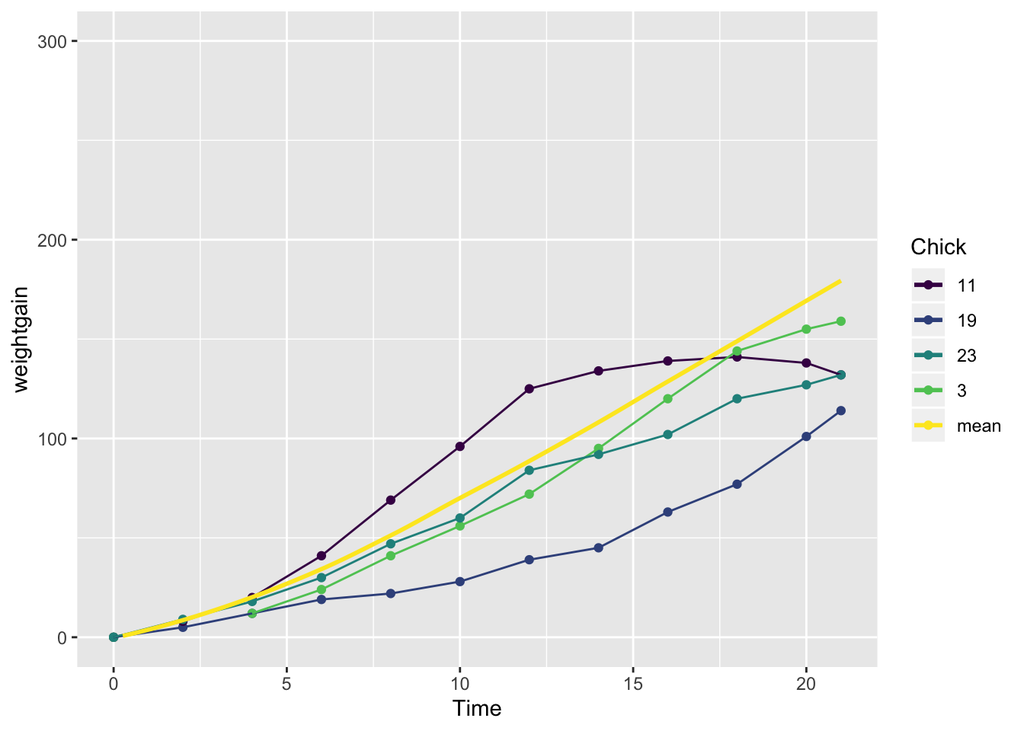

```r
dat5 <- group_by(complete, Time) %>% summarise(mean = mean(weightgain))
plot2 + geom_smooth(data = dat5, aes(x=Time, y = mean, color ="mean"), se=F) +ylim(0,300)
```

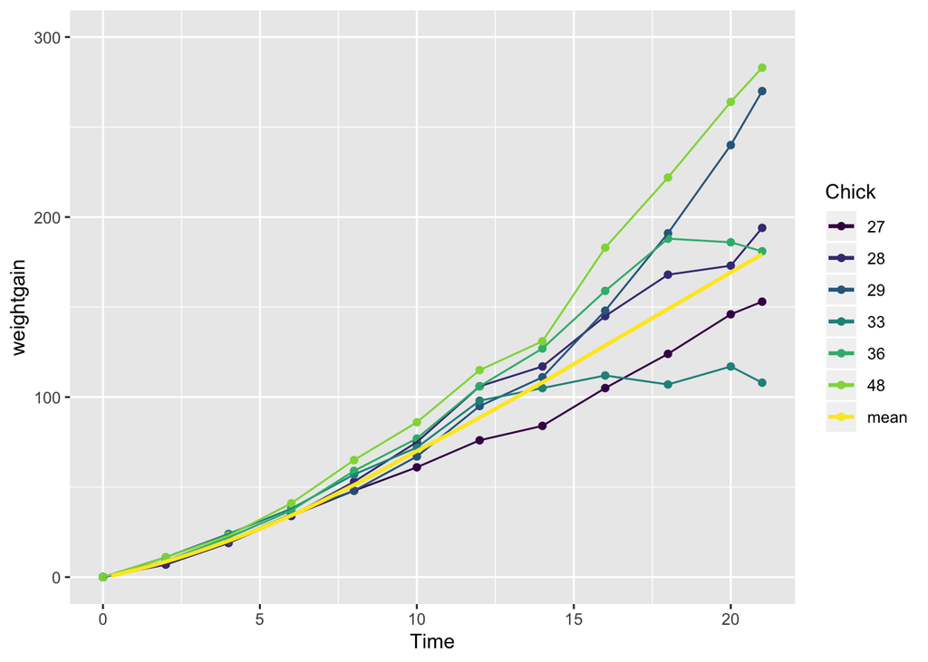

```r
plot3 + geom_smooth(data = dat5, aes(x=Time, y = mean, color ="mean" ), se=F) +ylim(0,300)
```

8. What else do you find interesting in the dataset? Show your exploratory analysis. What is relationship between the median growth trajectory and the chicks with the least and the most weight at time 0 for all chicks?

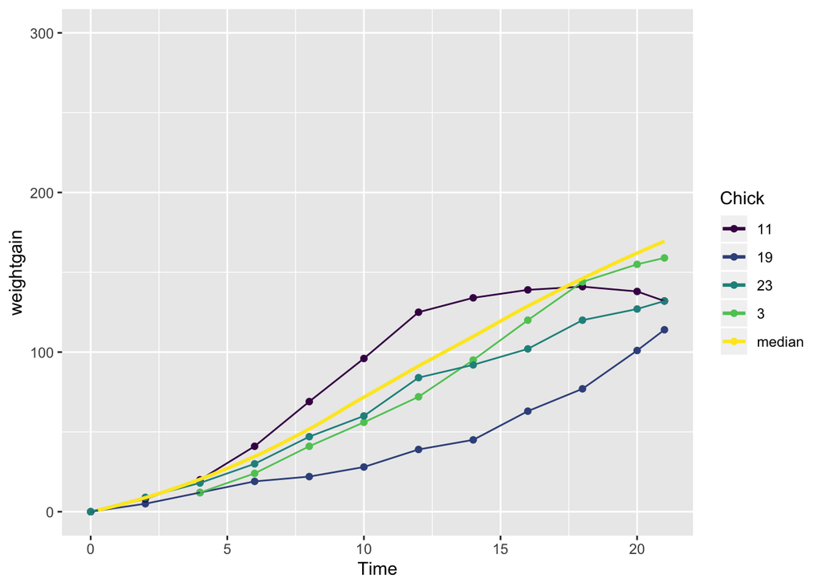

```r
dat6 <- group_by(complete, Time) %>% summarise(median = median(weightgain))
plot2 + geom_smooth(data = dat6, aes(x=Time, y = median, color ="median"), se=F) +ylim(0,300)
```

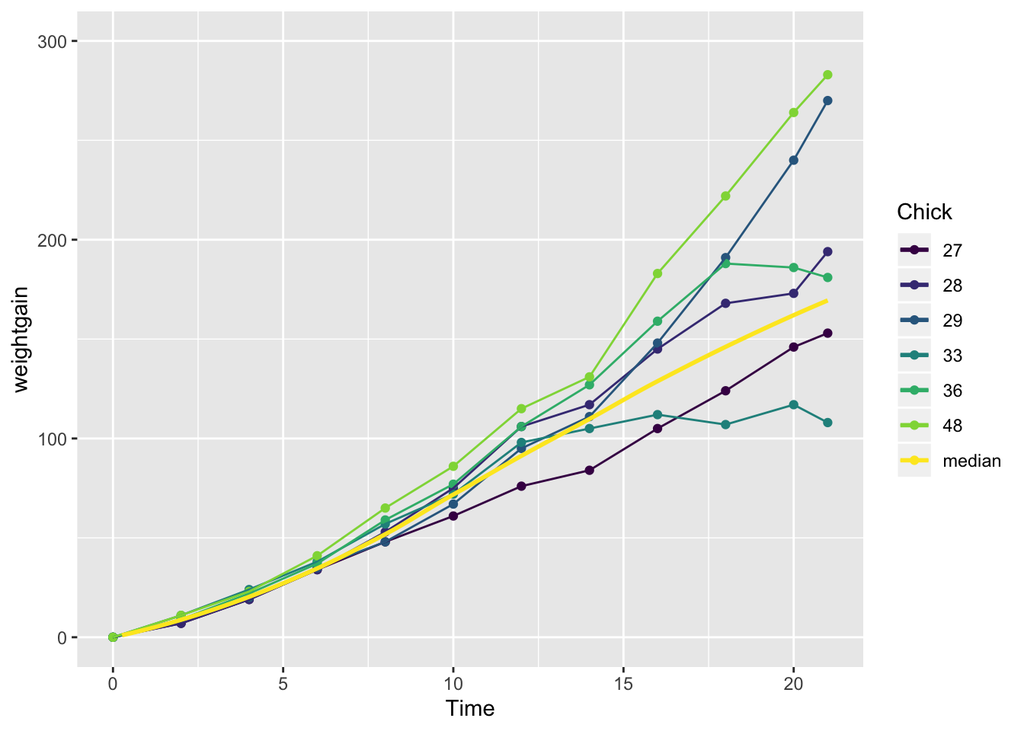

```r
plot3 + geom_smooth(data = dat6, aes(x=Time, y = median, color ="median" ), se=F) +ylim(0,300)
```

The relationship the median and growth rate of least and most weight are pretty similar with the mean. At time 20, Chick who has the maximum weight had a slower growth rate than the median but most chick who has the minimum weight had a larger growth rate than the median,except chick 27 and chick 33.